# Fitbit users insights for guided decisions

## 4. Analyze

We could start this section, summarizing the state of affairs, which would happen by saying that we have obtained as a product, two tables with which we are going to proceed with the analysis: -“fb_final_daily” -“fb_heartrateAvg”

Before starting the analysis is needed to mention that this section contains insights and ideas from the [MIGUEL FZZZ](https://www.kaggle.com/code/miguelfzzz/bellabeat-data-analysis-discovering-trends/report)design.

First, we need to set a theme for the plots:

```r
custom_theme_original <- function() {
  theme(
    panel.border = element_rect(colour = "black",
                                fill = NA,
                                linetype = 1),
    panel.background = element_rect(fill = "white",
                                    color = 'grey50'),
    panel.grid.minor.y = element_blank(),
    axis.text = element_text(colour = "blue",
                             face = "italic",
                             family = "Arial"),
    axis.title = element_text(colour = "gray",
                              family = "Arial"),
    axis.ticks = element_line(colour = "blue"),
    plot.title = element_text(size=20,
                              hjust = 0.5,
                              family = "Arial"),
    plot.subtitle=element_text(size=13,
                               hjust = 0.5),
    plot.caption = element_text(colour = "brown",
                                face = "Arial",
                                family = "Arial")
  )
}
```

### 4.1 Physiological activity:Heart-rate as a predictor of health problems

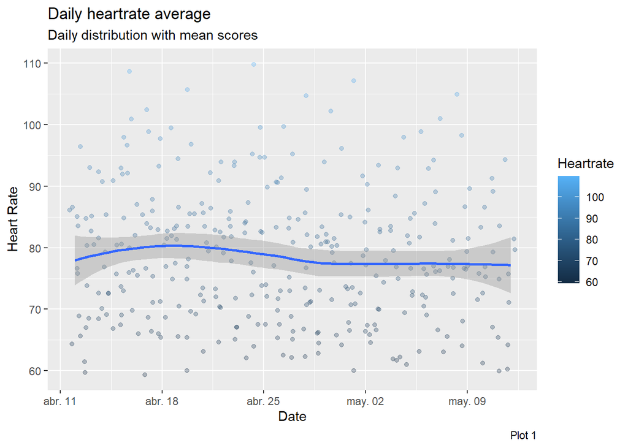

```r
fb_heartrateAvg %>%
  group_by(Id) %>%
  ggplot(aes(x=ymd, y=Heartrate,  color=Heartrate)) +
  geom_point(alpha=0.3, position = position_jitter())+
  geom_smooth()+
  labs(title = "Daily heartrate average", subtitle= "Daily distribution with mean scores", x= "Date", y="Heart Rate", caption = "Plot 1")
```

You can display an interactive plot by clicking **[here]**(https://public.tableau.com/app/profile/anbamo/viz/BellabeatInsightsfromFitbitHeartRate-Date/Physiological)

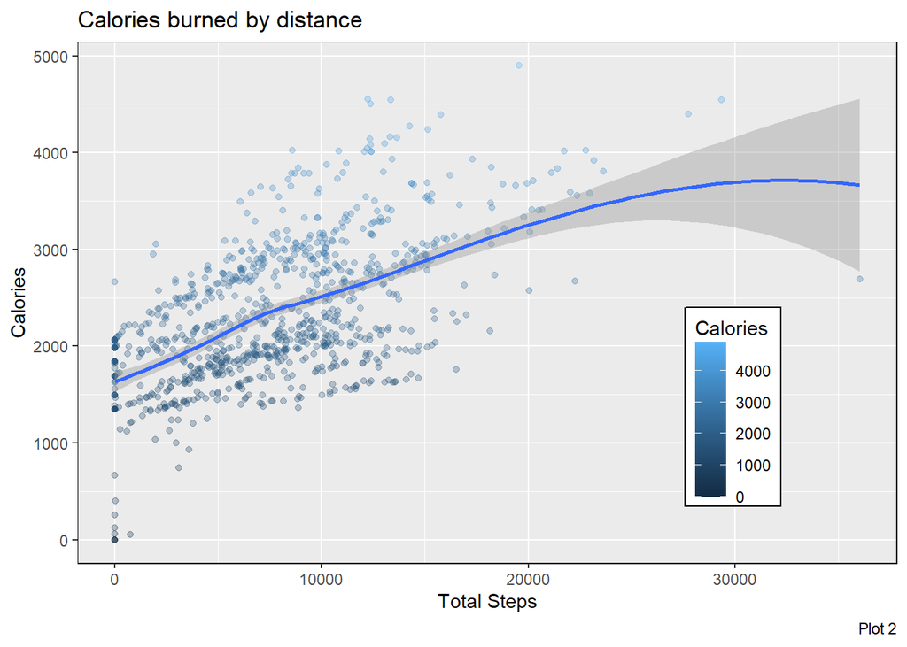

```r
fb_final_daily %>%
 group_by(TotalDistance, Calories) %>%
  ggplot(aes(x = TotalSteps, y = Calories, color = Calories)) +
  geom_point(alpha=0.3, position = position_jitter()) +
  geom_smooth() +
  theme(legend.position = c(.8, .3),
        legend.spacing.y = unit(1, "mm"),
        panel.border = element_rect(colour = "black", fill=NA),
        legend.background = element_blank(),
        legend.box.background = element_rect(colour = "black")) +
  labs(title = 'Calories burned by distance',
       y = 'Calories',
       x = 'Total Steps',
       caption = 'Plot 2')
```

**Pearson correlation index**

```r
cor.test(fb_final_daily$TotalDistance, fb_final_daily$Calories, method = 'pearson', conf.level = 0.95)
```

```
##
##  Pearson's product-moment correlation
##
## data:  fb_final_daily$TotalDistance and fb_final_daily$Calories
## t = 26.002, df = 941, p-value < 2.2e-16
## alternative hypothesis: true correlation is not equal to 0
## 95 percent confidence interval:
##  0.6078539 0.6822785
## sample estimates:
##       cor
## 0.6466023
```

You can display an interactive plot by clicking [here](https://public.tableau.com/app/profile/anbamo/viz/BellabeatInsightsfromFitbitcaloriesvsDistance/caloriesvsdistance)

### 4.3 Physical Activity 2: Calories by activity (total distance)

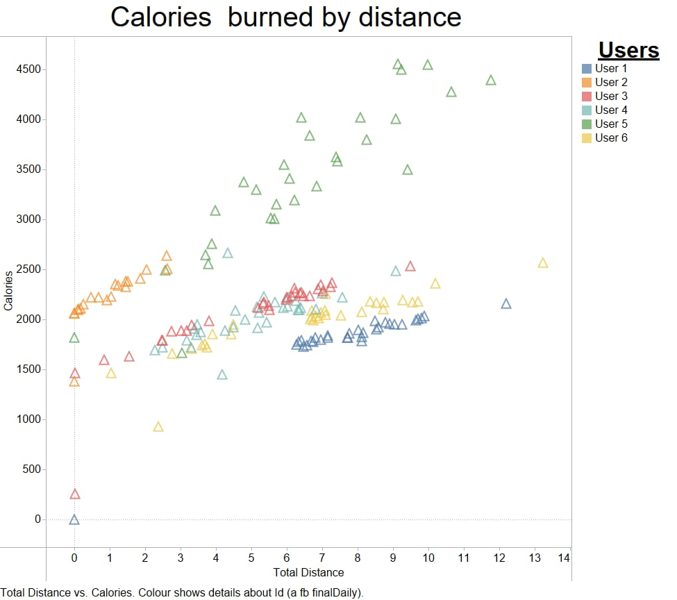

Plot 3: Daily Activity

### 4.4 Intensity of exercise activity

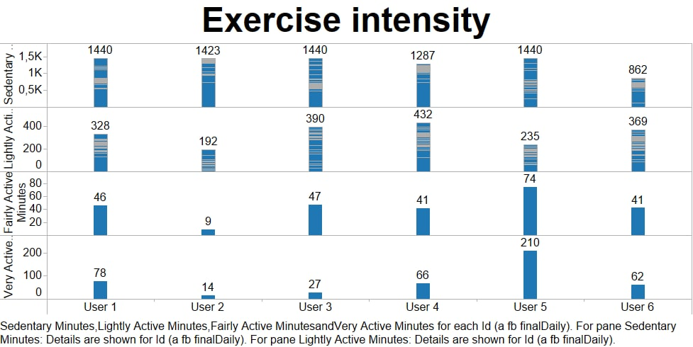

Plot 4: Excercise Intensity

You can display an interactive plot by clicking [here](https://public.tableau.com/app/profile/anbamo/viz/BellabeatInsightsfromFitbitExerciseintensity1/Exerciseintensity1)

### 4.5 Sleep distribution

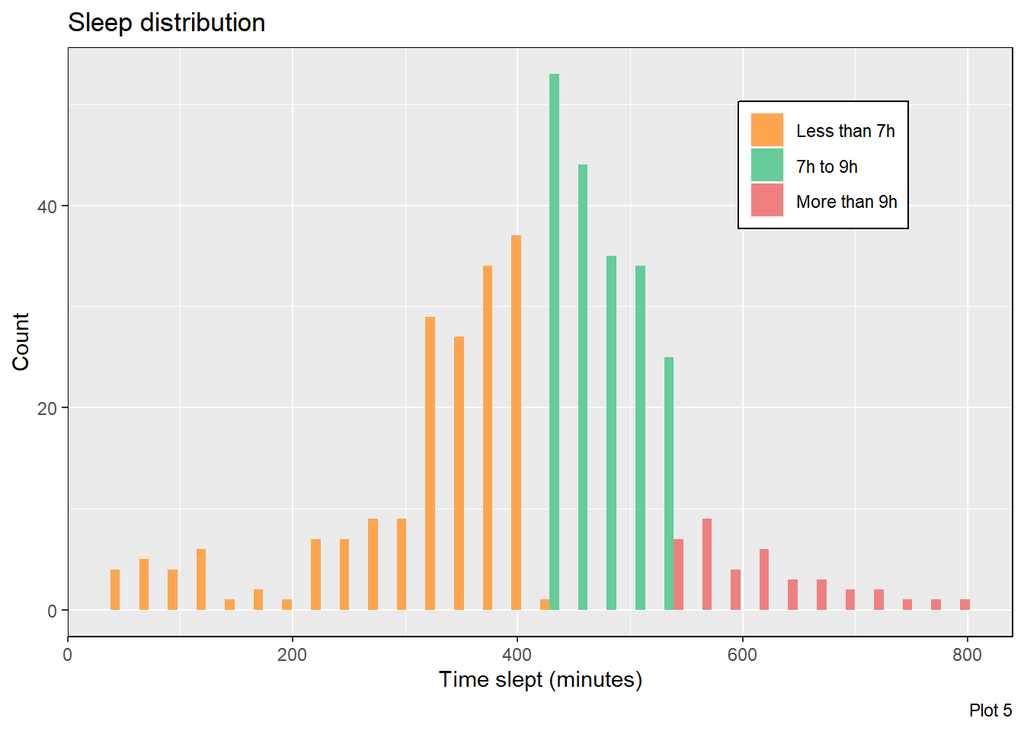

```r
fb_final_daily %>%
  select(TotalMinutesAsleep) %>%
  drop_na() %>%
  mutate(sleep_quality = ifelse(TotalMinutesAsleep <= 420, 'Less than 7h',
                         ifelse(TotalMinutesAsleep <= 540, '7h to 9h',
                         'More than 9h'))) %>%
  mutate(sleep_quality = factor(sleep_quality,
                          levels = c('Less than 7h','7h to 9h',
                                     'More than 9h'))) %>%
  ggplot(aes(x = TotalMinutesAsleep, fill = sleep_quality)) +
  geom_histogram(position = 'dodge', bins = 30) +
  scale_fill_manual(values=c("tan1", "#66CC99", "lightcoral")) +
  theme(legend.position = c(.80, .80),
        legend.title = element_blank(),
        legend.spacing.y = unit(0, "mm"),
        panel.border = element_rect(colour = "black", fill=NA),
        legend.background = element_blank(),
        legend.box.background = element_rect(colour = "black")) +
  labs(
    title = "Sleep distribution",
    x = "Time slept (minutes)",
    y = "Count",
    caption = 'Plot 5'
  )
```

### 4.6 Sleep vs distance covered

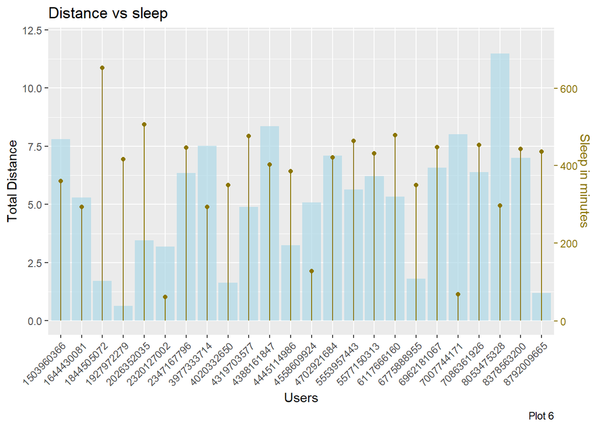

```r
fb_final_daily%>%
  select(Id, TotalDistance, TotalMinutesAsleep) %>%
  group_by(Id) %>%
  summarise_all(list(~mean(., na.rm=TRUE))) %>%
  drop_na() %>%
  mutate(Id = factor(Id)) %>%
  ggplot() +
  geom_bar(aes(x = Id, y = TotalDistance), stat = "identity", fill = 'lightblue', alpha = 0.7) +
  geom_point(aes(x = Id, y = TotalMinutesAsleep/60), color = 'gold4') +
  geom_segment(aes(x = Id, xend = Id, y = 0, yend = TotalMinutesAsleep/60), color = 'gold4' ,group = 1) +
  scale_y_continuous(limits=c(0, 12), name = "Total Distance",
    sec.axis = sec_axis(~.*60, name = "Sleep in minutes")) +
  theme(axis.text.x = element_text(angle = 45, hjust = 1)) +
  theme(axis.title.y.right = element_text(color = "gold4"),
        axis.ticks.y.right = element_line(color = "gold4"),
        axis.text.y.right = element_text(color = "gold4")) +
  labs(
    title = "Distance vs sleep",
    x = "Users",
    caption = 'Plot 6'
  )
```

## 5. Share

### 5.1. Weight key takeaways

#### 5.1.1 Weight as a key valor

1. Weight is one of the most important biometric measurements.
- As can be seen in [this interactive graph](https://public.tableau.com/app/profile/anbamo/viz/BellabeatInsightsfromFitbitExerciseintensity2/Exerciseintensity2), weight is a good predictor of physical activity, **in this case, the correlation between higher weight and lower intensity of physical activity and exercises**.
- In this [interactive graph](https://public.tableau.com/app/profile/anbamo/viz/BellabeatInsightsfromFitbitweightvsActivity/weightcalories), we can see easily that a higher weight is synonymous with shorter distances traveled.
- That the few users who entered their real weight did so manually, as we can see in this snapshot:

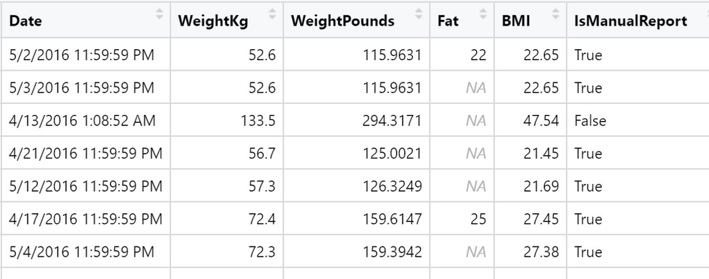

#### 5.1.2 Weight issues recomendations for “Bellabeat membership”

Weight is a recognized **medical risk factor for health**, but as we can deduce from the information analysed, we observe that it’s a great predictor of physical activity. The subscription service should encourage the user to provide biometric data, but especially the weight, as it’s vital for this subscription (pay) program to be really useful for our customers. In the same way, the technology behind scenes in the **app will be improves** for collect automatically the weight values. Finally, a rewards program should also be implemented to encourage physical activity.

### 5.2. Heart rate key takeways

#### 5.2.1. Heart rate monitorization

Abnormal cardiological activity and other health problems can be clearly reflected in the pulse with heart rate monitoring.

#### 5.2.2. Heart rate recomendations for “Bellabeat membership” and app

Both the subscription service and the app should implement artificial intelligence to understand when a heart rate is normal based on the physical activity that is taking place. Also manage to keep a record of the anomalies and the times that a high pulse has been had without correspondence of a physical activity that justifies it.